# Necklace

ryamada

2018年11月20日

# A method to find all necklaces in a mesh

A triangular mesh $T$ on n points, 1,2,…,n, is given along with positive weights on the $3n-6$ (Euler’s rule). This defines a shortest distances $d_{ij}$ for edge pair of points.

## Def:

A necklace is a cycle $C=c1,c2,..,ck,c1 $ in $T$ for which $d(ci,cj) = $ length of the shortest path on C between $ci$ and $cj$, and which partitions T into two non-empty parts.

## Def:

A shortes path tree $SPT(K)$ is a tree rooted at K that defines the shortest distance from K to all other points of T.

## Assumption (mostly technical for simplicity, can be removed removed in several ways):

There is a unique shortest path between each pair of points in T.

## Method

### Phase 1

1. For each $K \in \{1,...,n\}$ compute $SPT(K)$.
2. Each edge $uv$ of the remeining $2n-5 = 3n - 6 - (n-1)$ edges in $T$ creates a unique cycle $C_{uv}$ in $SPT(K_{uv})$.
- The idea using the remaining edges is used in the graph’s zeta function based on path ( http://math.ucsd.edu/~aterras/snowbird.pdf ).
3. Record $C_{uv}$ in a list if
- It is not a triangular face of $T$.
- It includes the root $K$ of $SPT(K)$.

### Phase 2

Let $C = c1,c2,...,ck,c1$ be a cycle in the list.

If $C$ appears in $SPT(j), j= c1,c2,...,ck$, then it is a necklace in $T$, otherwise it is not.

$C$ is written in canonical form so that $c1 < c2$ is the lexicographic smallest edge of $C$.

## Notes

1. Running time mostly dominated by computing $SPT(K)$ about $0(n^2 \log{n}$) and practical upto about $10^6$ nodes. Easy to parallelize!
2. Finding the necklaces from the cycle lists can be done in several ways, Eg;
- Merge lists, sort and count repetitions in one pass of sorted list
- “Hash” each cycle into a table counting the number of “collisions”.

## Implementation with R

Make an undirected weighted graph object.

The condition “It includes the root $K$ of $SPT(K)$” is ommited.

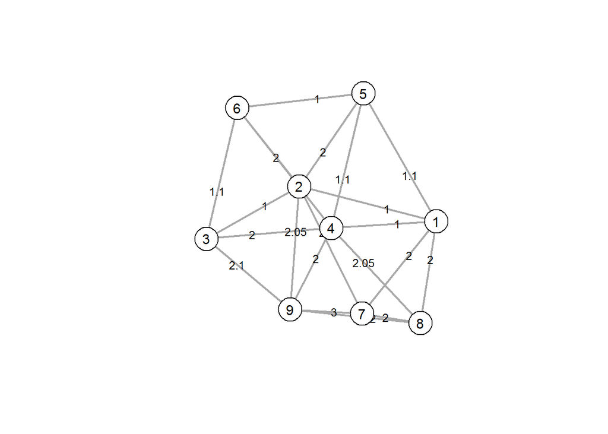

```r
# g: igraph's graph object
# w: edge length
library(igraph)
library(optrees)
el <- matrix(c(1,2,1,4,1,5,1,7,1,8,2,3,2,5,2,6,2,7,2,9,3,4,3,6,3,9,4,5,4,6,4,8,4,9,5,6,7,8,7,9,8,9),byrow=TRUE,ncol=2)
w <- c(1,1,1.1,2,2,1,2,2,2,2.05,2,1.1,2.1,1.1,1.2,2.05,2,1,2,3,2)
g <- graph.edgelist(el,directed=FALSE)

nv <- length(V(g))
ne <- length(E(g))

arcs <- cbind(el,w)
repGraph(1:nv,arcs)
```

Check the number of edges $ne = 3 nv -6$ (Euler’s formula for triangular mesh).

```r
ne == 3 * nv - 6
```

```
## [1] TRUE
```

Generate shortest paths from each node.

```r
spt <- list()
for(i in 1:nv){
  spt[[i]] <- shortest_paths(g,from=i,output="both",weights=w)
  spt[[i]]$remedge <- (1:ne)[-unlist(spt[[i]]$epath)]
}
```

Check the number of remaining edges is $2 nv - 5$.

```r
check.remedge <- rep(NA,nv)
for(i in 1:nv){
  check.remedge[i] <- length(spt[[i]]$remedge) == 2*nv - 5
}
check.remedge
```

```
## [1] TRUE TRUE TRUE TRUE TRUE TRUE TRUE TRUE TRUE
```

List up candicate cycles and record their component node ids (sorted).

```r
candC <- list()
for(i in 1:nv){
  #candC[[i]] <- list()
  for(j in 1:length(spt[[i]]$remedge)){
    this.edge <- el[spt[[i]]$remedge[j],]
    tmp1 <- spt[[i]]$vpath[[this.edge[1]]]
    tmp2 <- spt[[i]]$vpath[[this.edge[2]]]
    candC[[(i-1)*(2*nv-5) +j ]] <- sort(unique(c(tmp1,tmp2)))
  }
}
```

Convert the node ids of cycles into character strings.

```r
candC.txt <- sapply(candC,paste,collapse="_")
```

Count the cycles(character strings).

```r
tab <- table(candC.txt)
```

Get the number of nodes for each element of “tab” object.

```r
len.C <- (nchar(names(tab))+1)/2
```

Necklace with k nodes should appear k times. Based on this feature, necklaces should be extracted from candidates.

Necklace is defined as “no triangle” above. Below, necklaces including with triangles and without triangles are enumerated.

```r
necklaces <- which(tab==len.C)
necklaces.no.tri <- which(tab==len.C & len.C>3)
```

Show nodes of necklaces.

```r
strsplit(names(necklaces),split="_")
```

```
## [[1]]
## [1] "1" "2" "3" "4"
##
## [[2]]
## [1] "1" "2" "4" "9"
##
## [[3]]
## [1] "1" "2" "5"
##
## [[4]]
## [1] "1" "2" "7"
##
## [[5]]
## [1] "1" "4" "5"
##
## [[6]]
## [1] "1" "4" "7" "9"
##
## [[7]]
## [1] "1" "4" "8"
##
## [[8]]
## [1] "1" "7" "8"
##
## [[9]]
## [1] "2" "3" "6"
##
## [[10]]
## [1] "2" "3" "9"
##
## [[11]]
## [1] "2" "5" "6"
##
## [[12]]
## [1] "2" "7" "9"
##
## [[13]]
## [1] "3" "4" "6"
##
## [[14]]
## [1] "3" "4" "9"
##
## [[15]]
## [1] "4" "5" "6"
##
## [[16]]
## [1] "4" "8" "9"
##
## [[17]]
## [1] "7" "8" "9"
```

```r
strsplit(names(necklaces.no.tri),split="_")
```

```
## [[1]]
## [1] "1" "2" "3" "4"
##
## [[2]]
## [1] "1" "2" "4" "9"
##
## [[3]]
## [1] "1" "4" "7" "9"
```